# Project 2: Data Mining, Classification, Prediction

SDS322E

# Mining, Classification, Prediction

## Anita Rhodes, aar4395

### Introduction

The Original_Crabs dataset contains age, sex, height, length, diameter, and weight data on crabs in the Boston area. The weight data is separated into weight, shucked weight, viscera (internal organs) weight, and shell weight. For the sex variable, there are 3 different inputs–M (male), F (female), and I (indeterminate). In total, there are 3893 observations with 1435 for male, 1225 for female, and 1233 for indeterminate. The indeterminate observations were removed, resulting in the Crabs dataset with a total of 2660 observations.

Assuming there is a relationship between crap age and these various physical characteristic variables, this information could be very interesting/applicable to those in the crab farming industry.

```r
library(tidyverse)
# read your datasets in here, e.g., with read_csv()
Original_Crabs <- read_csv("CrabAgePrediction.csv")
Original_Crabs %>% group_by(Sex) %>% summarise(n())
```

```
## # A tibble: 3 x 2
##   Sex   `n()`
##   <chr> <int>
## 1 F      1225
## 2 I      1233
## 3 M      1435
```

```r
# if your dataset needs tidying, do so here
Crabs <- Original_Crabs %>% subset(Sex != "I")

Crabs <- rename(Crabs, ShellWeight = `Shell Weight`, VisceraWeight = `Viscera Weight`,
    ShuckedWeight = `Shucked Weight`)
Crabs <- Crabs %>% na.omit()
class_dat <- Crabs %>% select(Sex, Length:ShellWeight)
class_dat <- class_dat %>% mutate(Sex = ifelse(Sex == "F", 1,
    0))
# any other code here
```

### Cluster Analysis

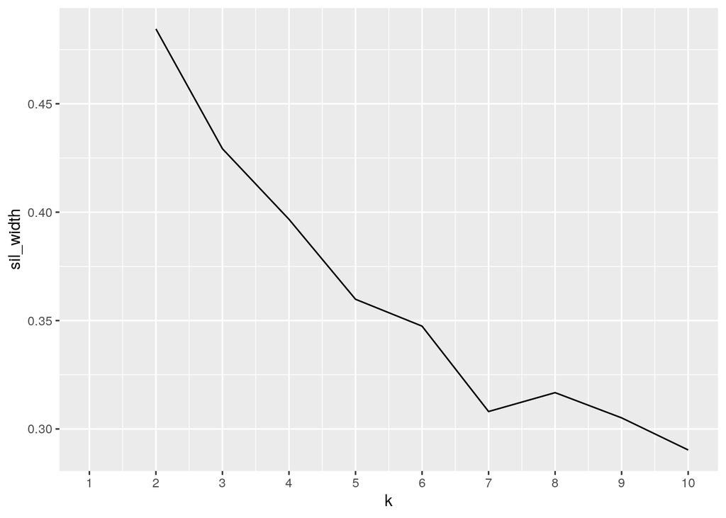

```r
library(cluster)
library(GGally)
# clustering code here
sil_width <- vector()
for (i in 2:10) {
    pam_fit <- pam(Crabs, k = i)
    sil_width[i] <- pam_fit$silinfo$avg.width
}
ggplot() + geom_line(aes(x = 1:10, y = sil_width)) + scale_x_continuous(name = "k",
    breaks = 1:10)  #use k=2
```

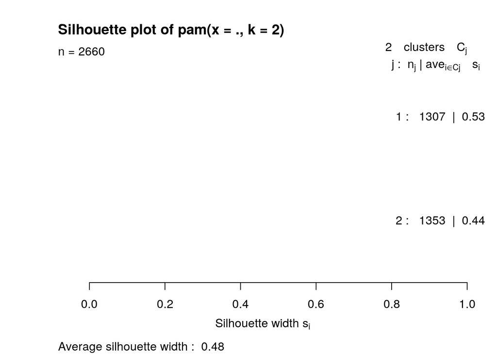

```r
Crab_pam <- Crabs %>% pam(k = 2)
plot(Crab_pam, which = 2)
```

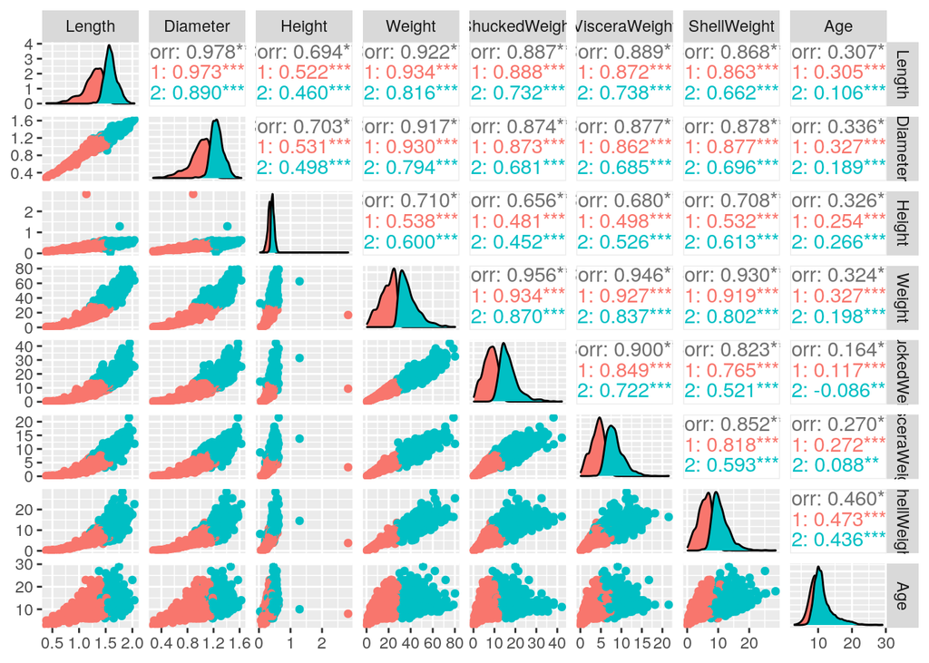

```r
Crabs %>% mutate(cluster = as.factor(Crab_pam$clustering)) %>%
    ggpairs(columns = 2:9, aes(color = cluster))
```

Discussion of clustering here With an average cluster silhouette of 0.48, the cluster solution is essentially in the middle between a reasonable and weak structure. Cluster 1 crabs (salmon colored) are light and have low lengths and diameters. While the heights are pretty equal for both clusters, this indicates that cluster 1 crabs are generally much smaller. Therefore, cluster 2 crabs are heavier with higher lengths and diameter.

### Dimensionality Reduction with PCA

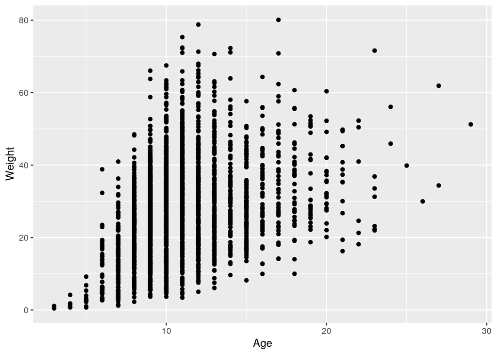

```r
ggplot(Crabs, aes(x = Age, y = Weight)) + geom_point()
```

```r
Crabnums <- Crabs %>% select_if(is.numeric) %>% scale

Crab_PCA <- princomp(Crabnums, center = T, cor = T)
summary(Crab_PCA, loadings = T)
```

```
## Importance of components:
##                           Comp.1    Comp.2     Comp.3     Comp.4     Comp.5
## Standard deviation     2.4897178 0.9705620 0.65103864 0.42717338 0.35753513
## Proportion of Variance 0.7748369 0.1177488 0.05298141 0.02280964 0.01597892
## Cumulative Proportion  0.7748369 0.8925857 0.94556710 0.96837674 0.98435566
##                            Comp.6     Comp.7      Comp.8
## Standard deviation     0.30751841 0.14525040 0.097413989
## Proportion of Variance 0.01182095 0.00263721 0.001186186
## Cumulative Proportion  0.99617660 0.99881381 1.000000000
##
## Loadings:
##               Comp.1 Comp.2 Comp.3 Comp.4 Comp.5 Comp.6 Comp.7 Comp.8
## Length         0.385         0.124  0.555                0.715
## Diameter       0.385         0.108  0.595               -0.696
## Height         0.315        -0.942
## Weight         0.394         0.132 -0.293        -0.135         0.845
## ShuckedWeight  0.373  0.255  0.135 -0.294  0.276 -0.670        -0.408
## VisceraWeight  0.378  0.129  0.124 -0.361  0.376  0.717        -0.193
## ShellWeight    0.378 -0.127        -0.182 -0.843               -0.286
## Age            0.157 -0.937  0.164         0.238
```

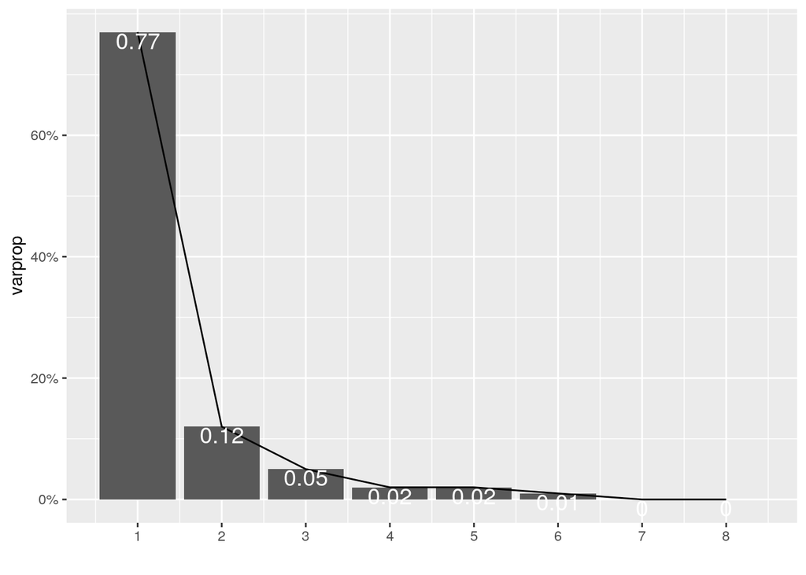

```r
eigval <- Crab_PCA$sdev^2
varprop = round(eigval/sum(eigval), 2)

ggplot() + geom_bar(aes(y = varprop, x = 1:8), stat = "identity") +
    xlab("") + geom_path(aes(y = varprop, x = 1:8)) + geom_text(aes(x = 1:8,
    y = varprop, label = round(varprop, 2)), vjust = 1, col = "white",
    size = 5) + scale_y_continuous(breaks = seq(0, 0.6, 0.2),
    labels = scales::percent) + scale_x_continuous(breaks = 1:10)
```

```r
round(cumsum(eigval)/sum(eigval), 2)  #keep 2 PCs
```

```
## Comp.1 Comp.2 Comp.3 Comp.4 Comp.5 Comp.6 Comp.7 Comp.8
##   0.77   0.89   0.95   0.97   0.98   1.00   1.00   1.00
```

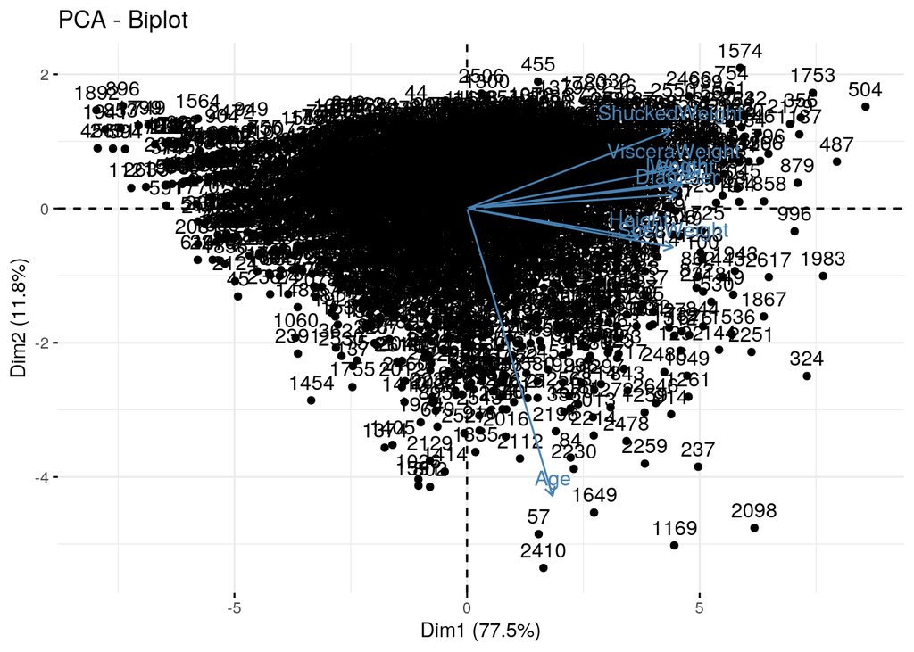

```r
library(factoextra)
fviz_pca_biplot(Crab_PCA)
```

PC1 is the general physical character data, so the higher the PC1 value, the stronger the variable is overall. PC2 is shucked/viscera weight vs shell weight and age. This means that the higher the shucked/viscera weight, the lower the shell weight and age, and vice versa. Further, 89.3% of the variance in Crabs is due to PC1 and PC2.

### Linear Classifier

```r
# linear classifier code here
glm(Sex ~ ., data = class_dat, family = "binomial")
```

```
##
## Call:  glm(formula = Sex ~ ., family = "binomial", data = class_dat)
##
## Coefficients:
##   (Intercept)         Length       Diameter         Height         Weight
##     -2.687972       0.384706       2.135058       1.303936      -0.005569
## ShuckedWeight  VisceraWeight    ShellWeight
##     -0.097775       0.080906      -0.005540
##
## Degrees of Freedom: 2659 Total (i.e. Null);  2652 Residual
## Null Deviance:       3671
## Residual Deviance: 3604  AIC: 3620
```

```r
fit <- glm(Sex ~ ., data = class_dat, family = "binomial")
probs <- predict(fit, type = "response")  #predictions
class_diag(probs, class_dat$Sex, positive = 1)  #performance
```

```
##            acc   sens   spec    ppv     f1     ba   auc
## Metrics 0.5628 0.3559 0.7394 0.5383 0.4285 0.5476 0.581
```

```r
table(truth = class_dat$Sex, predictions = probs > 0.5)  #confusion matrix
```

```
##      predictions
## truth FALSE TRUE
##     0  1061  374
##     1   789  436
```

```r
# cross-validation of linear classifier here

set.seed(1234)
k = 10
data <- class_dat[sample(nrow(class_dat)), ]
folds <- cut(seq(1:nrow(class_dat)), breaks = k, labels = F)

diags <- NULL
for (i in 1:k) {
    ## Create training and test sets
    train <- data[folds != i, ]
    test <- data[folds == i, ]
    truth <- test$Sex
    ## Train model on training set

    fit <- glm(Sex ~ ., data = train, family = "binomial")
    probs <- predict(fit, newdata = test, type = "response")
    ## Test model on test set (save all k results)
    diags <- rbind(diags, class_diag(probs, truth, positive = 1))
}

summarise_all(diags, mean)
```

```
##    acc    sens    spec     ppv      f1      ba     auc
## 1 0.55 0.34908 0.72399 0.51998 0.41567 0.53654 0.57141
```

For both the linear regression and CV this model is predicting observations badly giving the AUC values of .581 and .571 respectively. However, these AUC values are very close to each other indicating that there is no overfitting.

### Non-Parametric Classifier

```r
library(caret)
# non-parametric classifier code here

knn_fit <- knn3(Sex ~ ., data = class_dat, k = 15)
probs <- predict(knn_fit, newdata = class_dat)[, 2]  #we choose the second column since that's the probability of 'True'
class_diag(probs, class_dat$Sex, positive = 1)
```

```
##            acc   sens   spec    ppv     f1    ba    auc
## Metrics 0.6184 0.5306 0.6934 0.5963 0.5616 0.612 0.6671
```

```r
table(truth = class_dat$Sex, predictions = probs > 0.5)
```

```
##      predictions
## truth FALSE TRUE
##     0   995  440
##     1   575  650
```

```r
# cross-validation of np classifier here

set.seed(1234)
k = 15
data <- class_dat[sample(nrow(class_dat)), ]
folds <- cut(seq(1:nrow(class_dat)), breaks = k, labels = F)

diags <- NULL
for (i in 1:k) {
    ## Create training and test sets
    train <- data[folds != i, ]
    test <- data[folds == i, ]
    truth <- test$Sex
    ## Train model on training set

    knn_fit <- knn3(Sex ~ ., data = train)
    probs <- predict(knn_fit, newdata = test)[, 2]
    ## Test model on test set (save all k results)
    diags <- rbind(diags, class_diag(probs, truth, positive = 1))
}

summarise_all(diags, mean)
```

```
##         acc      sens      spec       ppv      f1        ba     auc
## 1 0.5289333 0.4660333 0.5846133 0.4893067 0.47466 0.5253133 0.53282
```

The non-parametric classifier is predicting observations poorly with an AUC value of .667. Meanwhile, the cross-validation is predicting badly with an AUC of only .532. Given that the CV predictions are worse than the classifier, overfitting may be occurring in this model. Further, the non-parametric classifier predicts observations better than the linear classifier when trained to the dataset, but worse when it comes to cross-validation.

### Regression/Numeric Prediction

```r
# regression model code here
fit <- lm(Age ~ ., data = Crabs)
yhat <- predict(fit)
mean((Crabs$Age - yhat)^2)  #MSE is 5.68
```

```
## [1] 5.68237
```

```r
# cross-validation of regression model here
k = 10  #choose number of folds
data <- Crabs[sample(nrow(Crabs)), ]  #randomly order rows
folds <- cut(seq(1:nrow(Crabs)), breaks = k, labels = F)  #create folds
diags <- NULL
for (i in 1:k) {
    train <- data[folds != i, ]
    test <- data[folds == i, ]
    ## Fit linear regression model to training set
    fit <- lm(Age ~ ., data = train)
    ## Get predictions/y-hats on test set (fold i)
    yhat <- predict(fit, newdata = test)
    ## Compute prediction error (MSE) for fold i
    diags <- mean((test$Age - yhat)^2)
}
mean(diags)  #average MSE is 6.56
```

```
## [1] 6.559348
```

### Python

```r
library(reticulate)
use_python("/usr/bin/python3", required = F)
Age_dat <- Crabs$Age
py$Age_range
```

[output not shown]

```python
# python code here
Age_dat=r.Age_dat
min(Age_dat)
```

```
## 3.0
```

```python
max(Age_dat)
```

```
## 29.0
```

```python
Age_range=max(Age_dat)-min(Age_dat)
```

### Concluding Remarks

Overall, each of the models and clustering had quite poor results. This may indicate that there is a very poor or weak relationship between crab measurements (length, weight, height, etc) and sex or age.